# Lab 05 - Multiple Linear Regression, model assessment

# The data

We have already seen how to read the dataset. We can either copy the code from last week - or use the file in Moodle and read it in:

```r
autompg <- read.csv(file = "autompg.csv")
```

We have a dataset with 7 variables: one dependent variable (`mpg`) and 6 predictors:

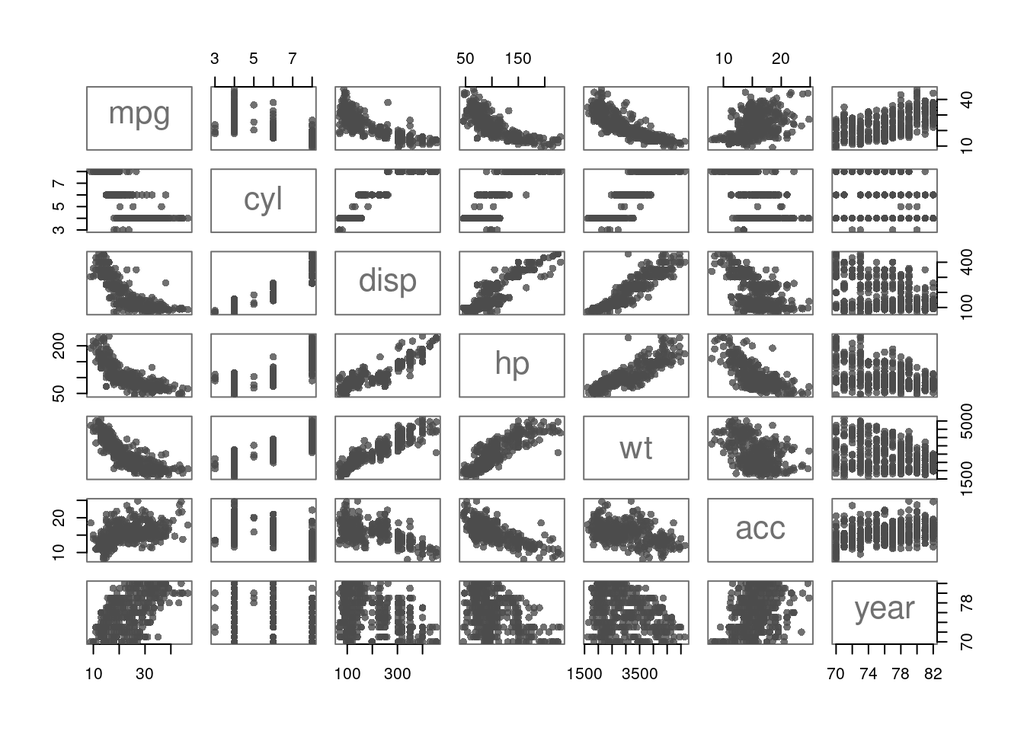

```r
## use rgb to define proportion of reg-green-blue in a color
## extra 4th argument is alpha - the transparency of the points
par(col= rgb(0.3,0.3,0.3,0.8),pch=16)
plot(autompg)
```

Some of the predictors appear to be more related to Y than others:

```r
signif(cor(autompg),3)
```

```
##         mpg    cyl   disp     hp     wt    acc   year
## mpg   1.000 -0.777 -0.805 -0.778 -0.832  0.426  0.579
## cyl  -0.777  1.000  0.951  0.843  0.897 -0.508 -0.342
## disp -0.805  0.951  1.000  0.897  0.933 -0.546 -0.368
## hp   -0.778  0.843  0.897  1.000  0.864 -0.692 -0.415
## wt   -0.832  0.897  0.933  0.864  1.000 -0.419 -0.306
## acc   0.426 -0.508 -0.546 -0.692 -0.419  1.000  0.295
## year  0.579 -0.342 -0.368 -0.415 -0.306  0.295  1.000
```

But important to also notice: they are related between each other!

# Models specification

Last week we had fitted a model with two explanatory variables:

$$Y_i = \beta_0 + \beta_{wt} \text{wt}_{i} + \beta_{year} \text{year}_{i} + \epsilon_i, \qquad i = 1, 2, \ldots, n$$
where $\epsilon_i \sim \mathcal{N}(0, \sigma^2)$ (and independent).

```r
fit_base <- lm(mpg~wt+year, data = autompg)
```

We can derive inference on the single $\beta_j$ parameters in the table provided by `summary` - but this only tells us about each $\beta$ when also taking the other variables in the model. What can we say about the significance of *the model* as a whole: does the model explain the variability of $Y$ better than a model based only on the mean (i.e. the simplest possible model?). We formalize this using the system of hypothesis:
$$H_0: \beta_{wt} = \beta_{year} = 0 \quad VS \quad H_1: \text{ any of } \beta_{wt} \text{ or } \beta_{year} \neq 0$$

Notice that under the null hypothesis the model reduces to
$$Y_i = \beta_0 + \epsilon_i, \qquad i = 1, 2, \ldots, n$$
a model which only includes a parameter to describe the mean.

The idea is to compare the sum of residuals obtained under the two different models. Eventually the test statistic we use can be shown to be:

$$F = \frac{\sum_{i=1}^{n}(\hat{Y}_{A,i} - \bar{Y})^2 / (p - 1)}{\sum_{i=1}^{n}(Y_i - \hat{Y}_{A,i})^2 / (n - p)},$$

```r
fit_null <- lm(mpg ~ 1, data = autompg)
anova(fit_null,fit_base)
```

```
## Analysis of Variance Table
##
## Model 1: mpg ~ 1
## Model 2: mpg ~ wt + year
##   Res.Df     RSS Df Sum of Sq      F    Pr(>F)
## 1    389 23761.7
## 2    387  4556.6  2     19205 815.55 < 2.2e-16 ***
## ---
## Signif. codes:  0 '***' 0.001 '**' 0.01 '*' 0.05 '.' 0.1 ' ' 1
```

Let’s see what each of the numbers in the table is. First the sum of squares:

```r
### SS under null (i.e. SStotal)
sum(fit_null$residuals^2); sum((autompg$mpg - mean(autompg$mpg))^2)
```

```
## [1] 23761.67
```

```
## [1] 23761.67
```

```r
## SS under alternative
sum(fit_base$residuals^2)
```

```
## [1] 4556.646
```

```r
## difference in Sum of Squares
sum(fit_null$residuals^2) - sum(fit_base$residuals^2)
```

```
## [1] 19205.03
```

```r
## this is equivalent to
sum((fit_null$fitted.values - fit_base$fitted.values)^2)
```

```
## [1] 19205.03
```

```r
### to compute the F:
# scale each Sum of Squares by the appropriate number of degrees of freedom
```

How many degrees of freedom does each the Sum of Square components have?

```r
## larger model (alternative)
fit_base$df.residual
```

```
## [1] 387
```

```r
## null model
fit_null$df.residual
```

```
## [1] 389
```

```r
## their difference
fit_null$df.residual - fit_base$df.residual
```

```
## [1] 2
```

Scale each of the Sum of Square components by the appropriate number of degrees of freedom:

```r
## Alternative model
sum(fit_base$residuals^2)/fit_base$df.residual
```

```
## [1] 11.77428
```

```r
## difference in Sum of Squares
(sum(fit_null$residuals^2) - sum(fit_base$residuals^2))/(fit_null$df.residual - fit_base$df.residual)
```

```
## [1] 9602.513
```

The F-statistic is:

```r
num <- (sum(fit_null$residuals^2) - sum(fit_base$residuals^2))/(fit_null$df.residual - fit_base$df.residual)
den <- sum(fit_base$residuals^2)/fit_base$df.residual
(Fstat <- num/den)
```

```
## [1] 815.5501
```

We can then compute the p-value using `pf` or check whether the $F_{obs}$ we have is large under a F distribution with 2 and 387 degrees of freedom:

```r
## p-value
pf(Fstat, df1 = fit_null$df.residual-fit_base$df.residual,
   df2 = fit_base$df.residual, lower.tail = FALSE)
```

```
## [1] 1.643078e-139
```

```r
### very small p-value
## Find the rejection region for the 1% significance test
qf(0.99,  df1 = fit_null$df.residual-fit_base$df.residual,
   df2 = fit_base$df.residual)
```

```
## [1] 4.660407
```

```r
### reject H_0 at 1% if Fstat > 4.666
## definitely reject
```

In practice rather than specifying the `fit_null` object we get the F-statistic value from the `summary`:

```r
summary(fit_base)$fstatistic
```

```
##    value    numdf    dendf
## 815.5501   2.0000 387.0000
```

indeed, R already does the p-value calculations in the printing of the summary

```r
summary(fit_base)
```

```
##
## Call:
## lm(formula = mpg ~ wt + year, data = autompg)
##
## Residuals:
##    Min     1Q Median     3Q    Max
## -8.852 -2.292 -0.100  2.039 14.325
##
## Coefficients:
##               Estimate Std. Error t value Pr(>|t|)
## (Intercept) -1.464e+01  4.023e+00  -3.638 0.000312 ***
## wt          -6.635e-03  2.149e-04 -30.881  < 2e-16 ***
## year         7.614e-01  4.973e-02  15.312  < 2e-16 ***
## ---
## Signif. codes:  0 '***' 0.001 '**' 0.01 '*' 0.05 '.' 0.1 ' ' 1
##
## Residual standard error: 3.431 on 387 degrees of freedom
## Multiple R-squared:  0.8082, Adjusted R-squared:  0.8072
## F-statistic: 815.6 on 2 and 387 DF,  p-value: < 2.2e-16
```

What about comparing different models with different number of predictor variables? Let’s fit a model with all explanatory variables in the dataset:

```r
fit_all <- lm(mpg~.,data = autompg)
### using the . (dot) is a shortcut to say: include everything
fit_all <- lm(mpg~cyl+disp+hp+wt+acc+year,data = autompg)
summary(fit_all)
```

```
##
## Call:
## lm(formula = mpg ~ cyl + disp + hp + wt + acc + year, data = autompg)
##
## Residuals:
##     Min      1Q  Median      3Q     Max
## -8.7162 -2.3918 -0.0473  2.0381 14.3386
##
## Coefficients:
##               Estimate Std. Error t value Pr(>|t|)
## (Intercept) -1.470e+01  4.772e+00  -3.081  0.00221 **
## cyl         -3.534e-01  3.335e-01  -1.060  0.28993
## disp         8.028e-03  7.376e-03   1.088  0.27709
## hp          -6.625e-04  1.387e-02  -0.048  0.96193
## wt          -6.791e-03  6.709e-04 -10.121  < 2e-16 ***
## acc          8.053e-02  1.026e-01   0.785  0.43297
## year         7.577e-01  5.289e-02  14.328  < 2e-16 ***
## ---
## Signif. codes:  0 '***' 0.001 '**' 0.01 '*' 0.05 '.' 0.1 ' ' 1
##
## Residual standard error: 3.439 on 383 degrees of freedom
## Multiple R-squared:  0.8093, Adjusted R-squared:  0.8064
## F-statistic:   271 on 6 and 383 DF,  p-value: < 2.2e-16
```

```r
## rquare and mse for two models
summary(fit_base)$r.square; sum(fit_base$residuals^2)
```

```
## [1] 0.8082355
```

```
## [1] 4556.646
```

```r
summary(fit_all)$r.square; sum(fit_all$residuals^2)
```

```
## [1] 0.8093372
```

```
## [1] 4530.466
```

but look what happens to confidence intervals for the function mean:

```r
nd <- data.frame(apply(autompg,2,quantile,c(0.01,0.5,0.9)))
(ci_all <- predict(fit_all,newdata = nd,interval = "conf"))
```

```
##          fit      lwr      upr
## 1%  26.23013 24.19137 28.26888
## 50% 24.77921 24.06877 25.48964
## 90% 19.01879 17.50895 20.52863
```

```r
(ci_base <- predict(fit_base,newdata = nd,interval = "conf"))
```

```
##          fit      lwr      upr
## 1%  26.90635 25.95849 27.85421
## 50% 24.57827 24.22949 24.92705
## 90% 18.64130 17.73176 19.55084
```

```r
ci_all[,3]-ci_all[,2]
```

```
##       1%      50%      90%
## 4.077509 1.420871 3.019683
```

```r
ci_base[,3]-ci_base[,2]
```

```
##        1%       50%       90%
## 1.8957202 0.6975514 1.8190836
```

```r
# (ci_null <- predict(fit_null,newdata = nd,interval = "conf"))
### also look at the uncertainty for the beta parameters for wt and year in the two models
```

Using too many predictors makes the prediction uncertain: we need to only keep predictors which are useful. Find a balance between being able to explain some variability but keeping the number of predictors low enough to avoid inflating the model variability. In statistics we say that we wish to find *parsimonious* models.